# Chapter 3 Multiple Linear Regression

### Hidden Extrapolation in Multiple Regression

**Similar to the simple linear regression, we want to prevent from making predictions that are essentially extrapolation in the multiple linear regression.**

For the delivery time example, suppose we want to make predictions at the following four data points.

| New observations symbol | NumberofCases | Distance |
| --- | --- | --- |
| a | 8 | 275 |
| b | 20 | 250 |
| c | 28 | 500 |
| d | 8 | 1200 |

Do these observations lead to extrapolation or not? How do we prevent from extrapolating? Note that the ranges of covariates are

```r
max(delivery$NumberofCases)
```

```
## [1] 30
```

```r
min(delivery$NumberofCases)
```

```
## [1] 2
```

```r
max(delivery$Distance)
```

```
## [1] 1460
```

```r
min(delivery$Distance)
```

```
## [1] 36
```

It seems these four observations are OK since they are within the ranges. But later we will show the **opposite** conclusion. **To answer the question of extrapolation in multiple linear regression, we need the concept of leverage.**

Here is an illustration of extrapolation in the multiple linear regression is below.

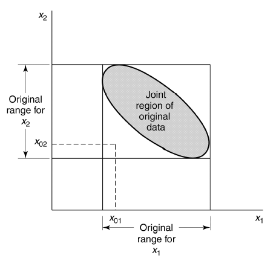

To prevent extrapolation, we need one additional tool called **leverage**. Leverage represents each data point’s distance to the center of the data set, it also measures each data point’s potential to influence the fitted linear regression. Each data point has one leverage value. In R, use `hatvalues(model1)` to obtain leverages.

For the delivery time example, we have obtained each data point’s leverage as follows.

```r
hatvalues(model1)
```

```
##          1          2          3          4          5          6          7
## 0.10180178 0.07070164 0.09873476 0.08537479 0.07501050 0.04286693 0.08179867
##          8          9         10         11         12         13         14
## 0.06372559 0.49829216 0.19629595 0.08613260 0.11365570 0.06112463 0.07824332
##         15         16         17         18         19         20         21
## 0.04111077 0.16594043 0.05943202 0.09626046 0.09644857 0.10168486 0.16527689
##         22         23         24         25
## 0.39157522 0.04126005 0.12060826 0.06664345
```

```r
cbind(delivery, leverage=hatvalues(model1))
```

```
##    Index DeliveryTime NumberofCases Distance   leverage
## 1      1        16.68             7      560 0.10180178
## 2      2        11.50             3      220 0.07070164
## 3      3        12.03             3      340 0.09873476
## 4      4        14.88             4       80 0.08537479
## 5      5        13.75             6      150 0.07501050
## 6      6        18.11             7      330 0.04286693
## 7      7         8.00             2      110 0.08179867
## 8      8        17.83             7      210 0.06372559
## 9      9        79.24            30     1460 0.49829216
## 10    10        21.50             5      605 0.19629595
## 11    11        40.33            16      688 0.08613260
## 12    12        21.00            10      215 0.11365570
## 13    13        13.50             4      255 0.06112463
## 14    14        19.75             6      462 0.07824332
## 15    15        24.00             9      448 0.04111077
## 16    16        29.00            10      776 0.16594043
## 17    17        15.35             6      200 0.05943202
## 18    18        19.00             7      132 0.09626046
## 19    19         9.50             3       36 0.09644857
## 20    20        35.10            17      770 0.10168486
## 21    21        17.90            10      140 0.16527689
## 22    22        52.32            26      810 0.39157522
## 23    23        18.75             9      450 0.04126005
## 24    24        19.83             8      635 0.12060826
## 25    25        10.75             4      150 0.06664345
```

The maximum of leverage, $h_{max}$, of existing data points is the 9-th observation with leverage of 0.4982922 as indicated below.

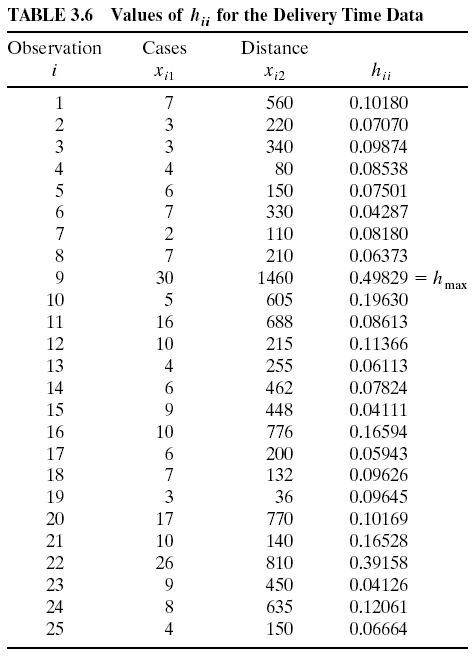

For a new observation that we need to predict, we can also calculate its leverage. To prevent extrapolation, make sure that the new observation’s leverage is less than the max of existing leverages. Let $x_{new}$ be a new observation at which prediction is of interest. Then its leverage is

$$h_{new}=x_{new}^T (X^T X)^{-1} x_{new}$$

where $x_{new}$ is a column vector with the first element being 1 and rest of elements being its covariates, and $X$ is the design matrix.

**If $h_{new} > h_{max}$ then the point is a point of extrapolation, otherwise, it is not, where $h_{max}$ is the maximum leverage of existing data points and $h_{new}$ is the leverage of the new data point being predicted.**

For example, a new observation with `NumberofCases = 8`, and `Distance = 275`, i.e., point a in the beginning of this section. Then $x_{new}$ is `c(1, 8 , 275)`.

```r
x_new=c(1,8,275) # first define a vector containing the covariate information. Note that we put 1 in the front of this vector.  This 1 is for the intercept.  So this 1 never changes.
```

The design matrix $X$ is

```r
X=model.matrix(model1)
X
```

```
##    (Intercept) NumberofCases Distance
## 1            1             7      560
## 2            1             3      220
## 3            1             3      340
## 4            1             4       80
## 5            1             6      150
## 6            1             7      330
## 7            1             2      110
## 8            1             7      210
## 9            1            30     1460
## 10           1             5      605
## 11           1            16      688
## 12           1            10      215
## 13           1             4      255
## 14           1             6      462
## 15           1             9      448
## 16           1            10      776
## 17           1             6      200
## 18           1             7      132
## 19           1             3       36
## 20           1            17      770
## 21           1            10      140
## 22           1            26      810
## 23           1             9      450
## 24           1             8      635
## 25           1             4      150
## attr(,"assign")
## [1] 0 1 2
```

The leverage of $x_{new}$, i.e., point a, can be obtained as

```r
# obtain the leverage for a new observation with NumberofCases=8 and Distance =275
t(x_new)%*%solve(t(X)%*%X)%*%x_new
```

```
##            [,1]
## [1,] 0.05397255
```

Therefore, the leverage of point a is 0.0539726 which is smaller than the $h_{max}=$0.4982922. Which means point a is not a extrapolation point. However, suppose we want to make prediction for all four observations.

```r
# similarly, we could calculate the hii for new observations with NumberofCases=20, Distance 250 (or NumberofCases=28, Distance 500, or NumberofCases=8, Distance 1200).
x_newb=c(1,20,250)
t(x_newb)%*%solve(t(X)%*%X)%*%x_newb
```

```
##           [,1]
## [1,] 0.5891742
```

```r
x_newc=c(1,28,500)
t(x_newc)%*%solve(t(X)%*%X)%*%x_newc
```

```
##           [,1]
## [1,] 0.8987353
```

```r
x_newd=c(1,8,1200)
t(x_newd)%*%solve(t(X)%*%X)%*%x_newd
```

```
##          [,1]
## [1,] 0.867362
```

Since their leverages are larger than $h_{max}=$0.4982922. These point b, c, and d are all extrapolation. Here is a summary.

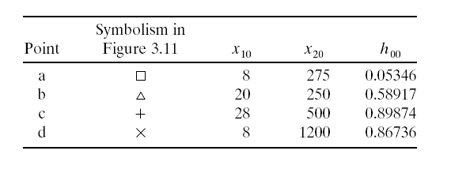

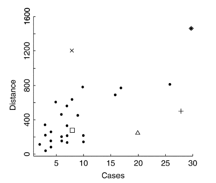

### What Decides the Leverage?

Finally, we plot the contour of leverage values of all possible data points given the observed data points on the left. The black dots are the original data points which decide the contour, the blue dots are the new observations to be predicted. On the right, we add the four data points. As we can see, only one point falls in the middle of the contour. The other three are outside of the largest contour curve that contains the original data points.

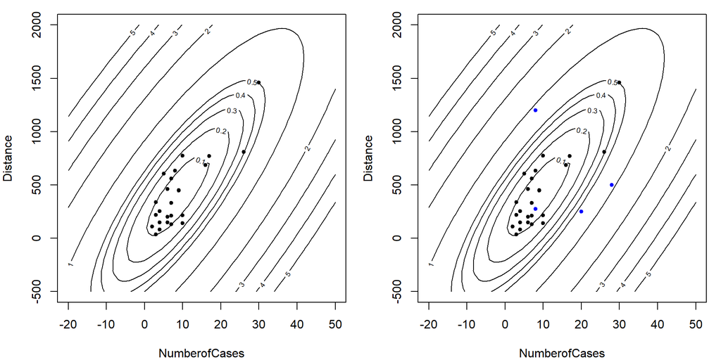